# 02 · Quantification

## Load packages

```r
pacman::p_load(here, limpa, limma, tibble, readxl, writexl)
here::i_am("01_Preprocess/02_Quantification/a_script/02_quantify.qmd")
```

## Read measurements and protein estimates

`dpcQuant()` takes about 100 minutes, so `02_quantify_run.R` writes a checkpoint; the check below fails when filtering has changed since.

```r
y <- readRDS(here("01_Preprocess", "01_Filtering", "c_data", "precursors_filtered.rds"))
checkpoints <- here("01_Preprocess", "02_Quantification", "c_data", "quant_runs")
proteins <- readRDS(file.path(checkpoints, "proteins_slope_0.7.rds"))
stopifnot(sum(proteins$genes$NPrec) == nrow(y))
```

## Missingness

Low-intensity precursors go missing more often in DIA data, which is why missing values are modelled rather than filtered.

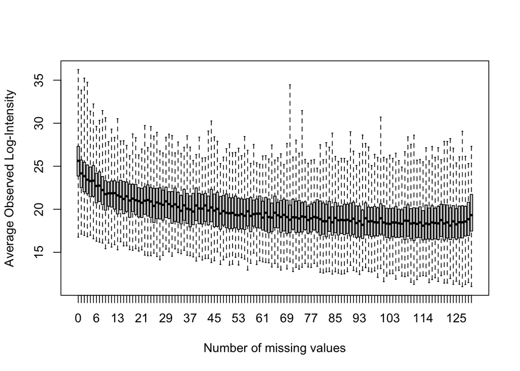

```r
plotAveVsMis(y)
```

## Fit the detection curve

The detection probability curve (DPC) is a logistic function of true intensity; `dpc()` uses `dpcCN()`, the estimator the limpa FAQ recommends for noisy data.

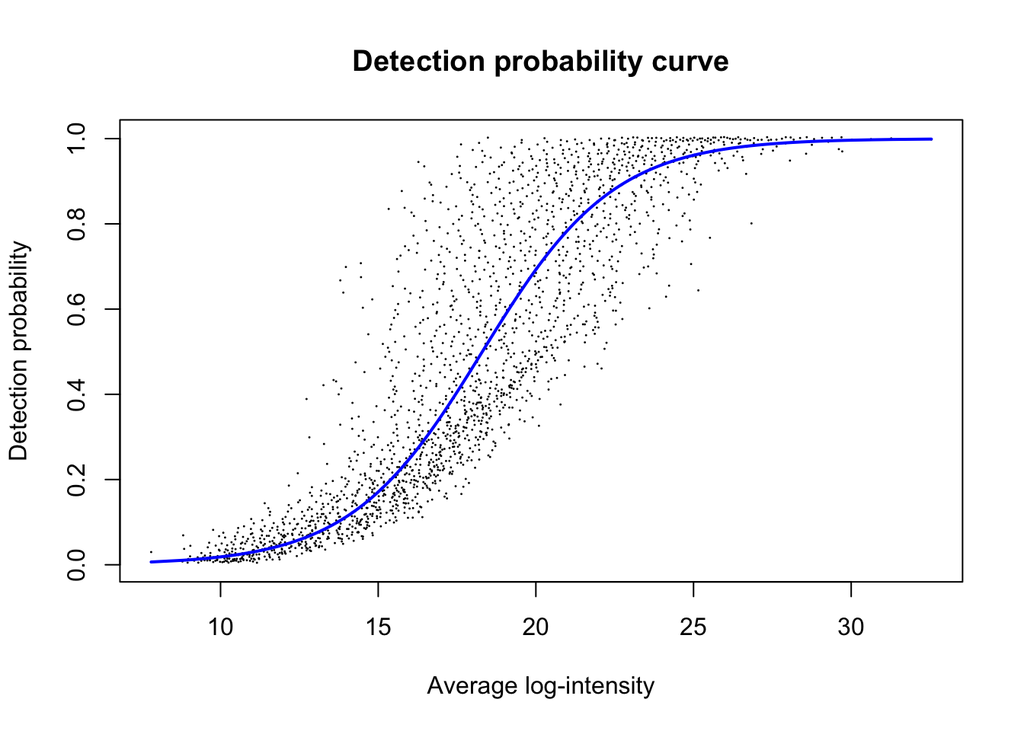

```r
dpcest <- dpc(y$E)
plotDPC(dpcest)
```

```r
dpc_parameters <- tibble(intercept = dpcest$dpc[1], slope = dpcest$dpc[2])
round(dpc_parameters, 3)
```

```
# A tibble: 1 × 2
  intercept slope
      <dbl> <dbl>
1     -8.76 0.478
```

The fitted slope, 0.478, is below the 0.7 to 0.9 the limpa FAQ calls typical, so the primary run presets `dpc.slope = 0.7` as the FAQ advises; the fitted slope is a sensitivity run.

## Roll-up

`dpcQuant()` returns a complete matrix with a standard error per value, which `dpcDE()` later uses to predict each protein’s variance.

```r
round(proteins$dpc, 3)
```

```
  beta0   beta1
-12.915   0.700
```

## Detection filter

The threshold is the smallest group size, since the help page leaves it to the analyst; the count runs across all samples, so it does not guarantee detection within a group.

```r
group_sizes <- table(proteins$targets$group)
detected <- filterByDetection(proteins, n.samples = min(group_sizes))
proteins <- proteins[detected, ]

detection_summary <- data.frame(
  before = length(detected), kept = sum(detected), dropped = sum(!detected),
  minimum_samples = min(group_sizes)
)

group_sizes
```

```
 BFR_T1  BFR_T2 HLRT_T1 HLRT_T2
     33      32      33      33
```

```r
detection_summary
```

```
  before kept dropped minimum_samples
1   3451 3042     409              32
```

## Normalisation

DIA-NN normalised only the precursors, and Smyth recommends cyclic loess for limpa protein estimates when sample differences are technical ([Bioconductor support](https://support.bioconductor.org/p/9163187/#9163221)). It subtracts an abundance-dependent offset without rescaling, so the standard errors still apply.

```r
unnormalised <- proteins$E
proteins$E <- normalizeBetweenArrays(proteins$E, method = "cyclicloess")
```

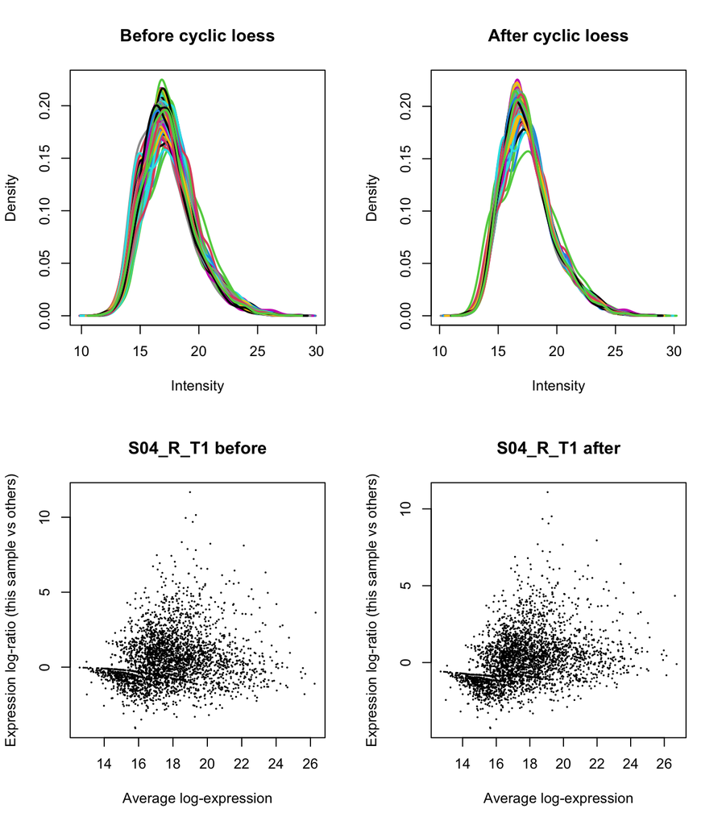

```r
sample_medians <- apply(unnormalised, 2, median)
worst <- which.max(abs(sample_medians - median(sample_medians)))
par(mfrow = c(2, 2))
plotDensities(unnormalised, legend = FALSE, main = "Before cyclic loess")
plotDensities(proteins$E, legend = FALSE, main = "After cyclic loess")
plotMD(unnormalised, column = worst, main = paste(colnames(unnormalised)[worst], "before"))
plotMD(proteins$E, column = worst, main = paste(colnames(proteins$E)[worst], "after"))
```

## Blood index

HBB and HBA1 come only from red cells, so their mean log2 estimate, centred, measures how much blood a biopsy holds; later stages model it. The contamination load from `01_Filtering` is kept beside it for reference.

```r
haemoglobin <- readRDS(
  here("01_Preprocess", "01_Filtering", "c_data", "haemoglobin_precursors.rds")
)
stopifnot(identical(colnames(haemoglobin), colnames(proteins)))
haemoglobin_estimates <- dpcQuant(
  haemoglobin, "Protein.Group", dpc = proteins$dpc, verbose = FALSE
)
blood <- colMeans(haemoglobin_estimates$E)
proteins$targets$blood <- blood - mean(blood)

contamination <- read_xlsx(
  here("01_Preprocess", "01_Filtering", "c_data", "01_filter.xlsx"), "sample_contamination"
)
proteins$targets$contamination <- contamination$pct_signal_removed[
  match(proteins$targets$sample_id, contamination$sample_id)
]
stopifnot(!anyNA(proteins$targets$contamination))
```

```r
round(cor(haemoglobin_estimates$E[1, ], haemoglobin_estimates$E[2, ]), 3)
```

```
[1] 0.903
```

```r
round(cor(proteins$targets$blood, proteins$targets$contamination, method = "spearman"), 3)
```

```
[1] 0.885
```

```r
round(tapply(proteins$targets$blood, proteins$targets$group, median), 3)
```

```
 BFR_T1  BFR_T2 HLRT_T1 HLRT_T2
 -0.302   0.301   0.580  -0.016
```

## Check protein estimates

Mean standard errors and observation counts show which proteins are thinly measured.

```r
# dpcQuant() writes the precursor count as NPrec, though its help page says NPeptides.
protein_quality <- tibble(
  protein = rownames(proteins),
  gene = proteins$genes$Genes,
  n_precursors = proteins$genes$NPrec,
  prop_observed = proteins$genes$PropObs,
  mean_log2 = rowMeans(proteins$E),
  mean_standard_error = rowMeans(proteins$other$standard.error),
  mean_n_observations = rowMeans(proteins$other$n.observations)
)
summary(protein_quality[c("mean_log2", "mean_standard_error", "prop_observed")])
```

```
   mean_log2     mean_standard_error prop_observed
 Min.   :12.98   Min.   :0.03108     Min.   :0.03716
 1st Qu.:16.07   1st Qu.:0.38547     1st Qu.:0.30245
 Median :17.10   Median :0.58461     Median :0.42324
 Mean   :17.52   Mean   :0.65933     Mean   :0.43276
 3rd Qu.:18.63   3rd Qu.:0.91543     3rd Qu.:0.54962
 Max.   :26.78   Max.   :1.50295     Max.   :0.97710
```

## Sample map

`plotMDSUsingSEs()` weights the distances by the standard errors; participant should dominate the first coordinate if the paired design is right.

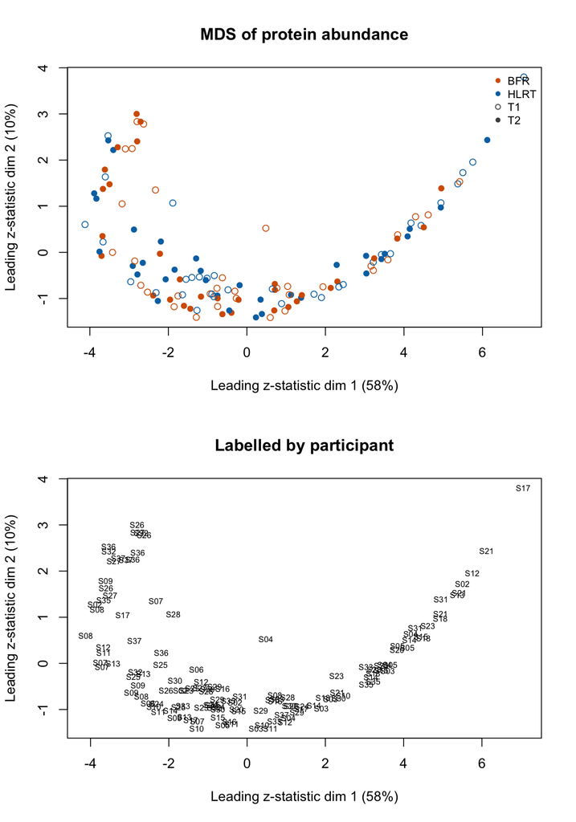

```r
mds <- plotMDSUsingSEs(proteins, plot = FALSE)
treatment_colours <- c(BFR = "#D55E00", HLRT = "#0072B2")
draw_mds <- function() {
  par(mfrow = c(2, 1))
  plotMDS(mds, col = treatment_colours[proteins$targets$treatment],
    pch = c(T1 = 1, T2 = 16)[proteins$targets$timepoint], main = "MDS of protein abundance")
  legend("topright", c(names(treatment_colours), "T1", "T2"), bty = "n", cex = 0.8,
    col = c(treatment_colours, "grey30", "grey30"), pch = c(16, 16, 1, 16))
  plotMDS(mds, labels = proteins$targets$participant, cex = 0.6, main = "Labelled by participant")
}
draw_mds()
```

```r
pdf(here("01_Preprocess", "02_Quantification", "b_reports", "02_quantify.pdf"),
  width = 8.27, height = 11.69)
draw_mds()
invisible(dev.off())
round(sapply(proteins$targets[c("participant", "group")], function(f) {
  summary(lm(mds$x ~ factor(f)))$r.squared
}), 3)
```

```
participant       group
      0.515       0.027
```

## Slope sensitivity

Hit counts cannot show which slope is right, so the fitted-curve run gets the same filter and normalisation and `02_Differential` compares its contrasts. It runs only when the checkpoint exists.

```r
sensitivity <- readRDS(file.path(checkpoints, "proteins_slope_fitted.rds"))
sensitivity <- sensitivity[filterByDetection(sensitivity, n.samples = min(group_sizes)), ]
sensitivity$E <- normalizeBetweenArrays(sensitivity$E, method = "cyclicloess")
stopifnot(identical(rownames(sensitivity), rownames(proteins)))

tibble(
  role = c("primary", "sensitivity"),
  intercept = round(c(proteins$dpc[1], sensitivity$dpc[1]), 3),
  slope = round(c(proteins$dpc[2], sensitivity$dpc[2]), 3),
  mean_standard_error = round(c(
    mean(proteins$other$standard.error), mean(sensitivity$other$standard.error)
  ), 3)
)
```

```
# A tibble: 2 × 4
  role        intercept slope mean_standard_error
  <chr>           <dbl> <dbl>               <dbl>
1 primary        -12.9  0.7                 0.659
2 sensitivity     -8.76 0.478               0.526
```

```r
round(median(abs(proteins$E - sensitivity$E)), 4)
```

```
[1] 0.2458
```

## Save results

Models with a design carry the blood index as a covariate; steps that take no design (singscore, WGCNA, mixOmics) need it removed first, with group and participant protected.

```r
out <- here("01_Preprocess", "02_Quantification", "c_data")
saveRDS(proteins, file.path(out, "proteins.rds"))
adjusted <- proteins
adjusted$E <- removeBatchEffect(
  proteins$E, covariates = proteins$targets$blood,
  design = model.matrix(~ 0 + group + participant, proteins$targets)
)
saveRDS(adjusted, file.path(out, "proteins_adjusted.rds"))
write_xlsx(
  list(
    dpc_parameters = dpc_parameters,
    detection_summary = detection_summary,
    protein_quality = protein_quality
  ),
  file.path(out, "02_quantify.xlsx")
)
```